# Tarea 03

2022-06-05

[figure not shown]

#### Universidad Alberto Hurtado

#### Carrera: Sociología

#### Profesora: Valentina Andrade de la Horra

#### Ayudantes: Nicolás Godoy Marquéz y Dafne Jaime Vargas

#### Estudiantes: Josefa Espinoza - Camilo Riquelme - Isidora Toledo

##Presentacion de la base Con motivo de esta tarea trabajaremos con los datos de la encuesta longitudinal social del centro de estudios de conflicto y cohesión social (COES) del año 2019, la cual posee 3417 observaciones y 374 variables, de las cuales trabajaremos solo con 9, estas son: a) c20 -> 44 ¿Cuál es el movimiento social que ud. más valora? b) c22 -> 45 Frecuencia de participacion en movimientos sociales c) c41_01 -> 53 Grado de rabia: Actuales niveles de desigualdad en Chile d) c41_02 -> Grado de rabia: El costo de la vida en Chile e) c16 -> 58 ¿Cuál de los siguientes partidos políticos representa mejor sus intereses, creencias y valores? f) c18_04 -> 74 Grado de acuerdo: Mas que derechos necesitamos un gobierno firme g) c18_05 -> 74 Grado de acuerdo: Pais necesita un mandatario fuerte h) c18_06 -> 74 Grado de acuerdo: Obediencia y respeto importantes que aprendan los ninnios i) c18_07 -> 4 Grado de acuerdo: Obediencia y disciplina son claves para buena vida

# Tablas y Graficos

##¿Cuál es el movimiento social que ud. más valora?

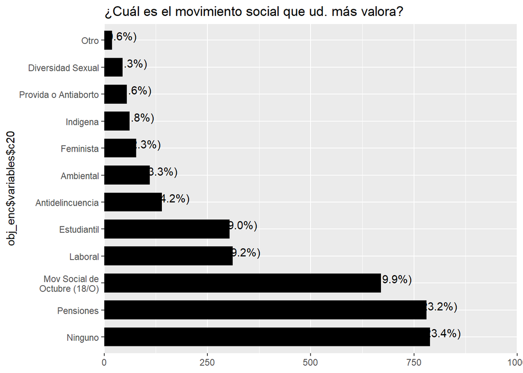

Para desarrollar el analisis de este gráfico tomaremos en consideracion dos respuestas, la primera será la cateforia de “ninguna” la cual representa a un 23,4% de la muestra, en el reporte original esta variable posee un 18% aproximadamente de representatividad. Si bien nos acercamos al resultado, creemos que hay un error en el procesamiento que no podemos identificar. La segunda respuesta a descrbir es la opcion de “pensiones” la cual representa a un 23,2% de la muestra, en este caso si nos acercamos al valor de los resultados originales.

##¿Cuál de los siguientes partidos políticos representa mejor sus intereses, creencias y valores?

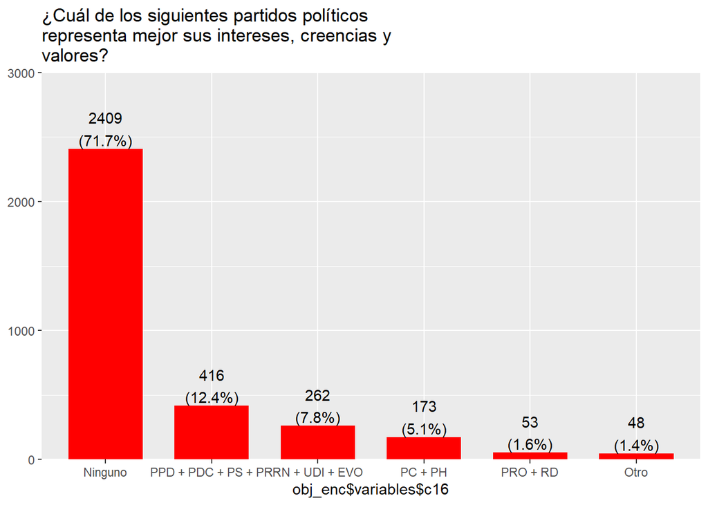

Para la elaboración de nuestro gráfico, utilizamos los datos correspondientes al año 2019, año en el que la barra “ninguno” concentraba el 67.5% de los casos de la muestra, la barra “otro” el 1,2%, la barra “R+ UDI+ EVO” un 9,7%, la barra “PPD+ PDC+ PS+ PR” un 13,2%. La barra “PRO+ RD” un 3,0% y,la barra “PD+ PH” un 5,5%.

##Frecuencia de participacion en movimientos sociales

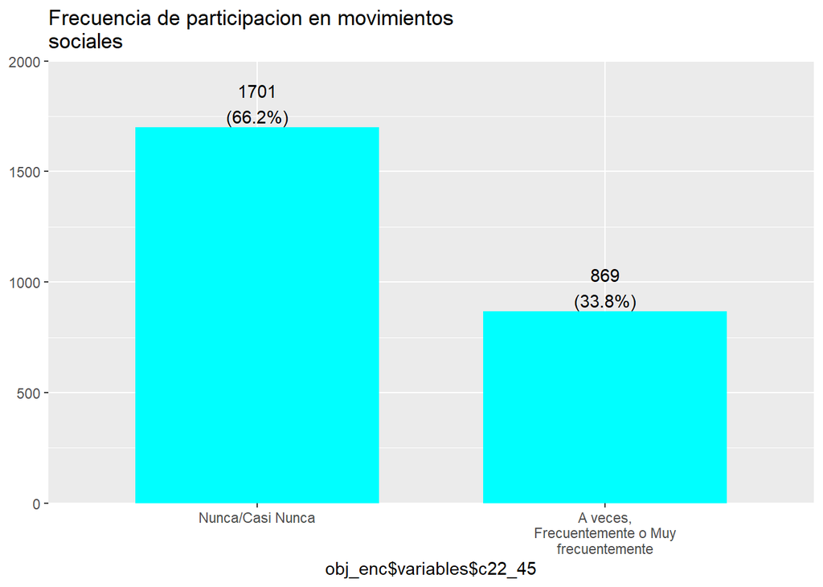

El grafico original para el año 2019 presentaba un 36,3% de frecuencia de participacion en movimientos sociales, recopilando las categorias de “A veces”, “Frecunetemente” y “Muy Frecuentemente”. Nuestro grafico nos da un resultado de 33, 8% de participación, nuevamente no podemos identificar el problema en la diferencia de datos.

###Frecuencia de participación en movimiento social, según rabia hacia nivel de desigualdad

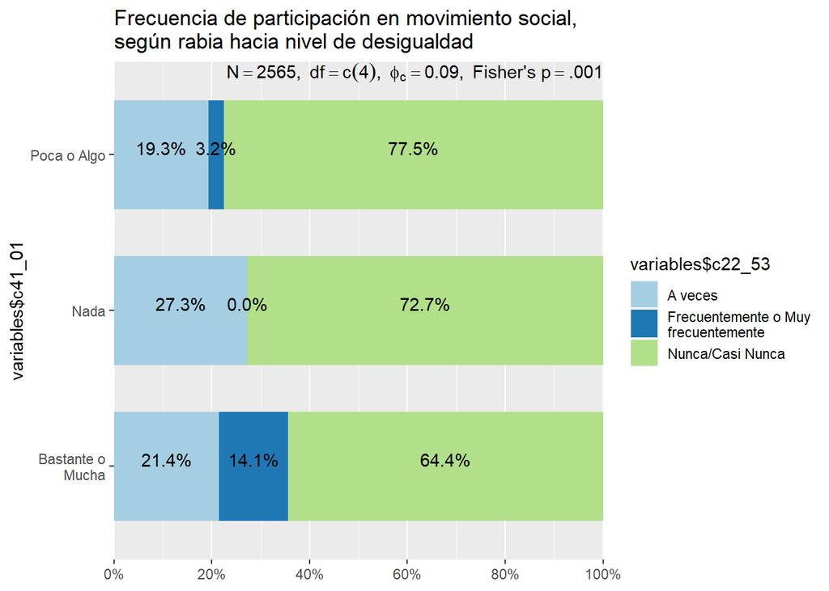

En este caso tenemmos una diferencia aprocimada de 10pts del marco referencial original de la encuesta.

##Frecuencia de participación en movimiento social, según rabia hacia costo de vida

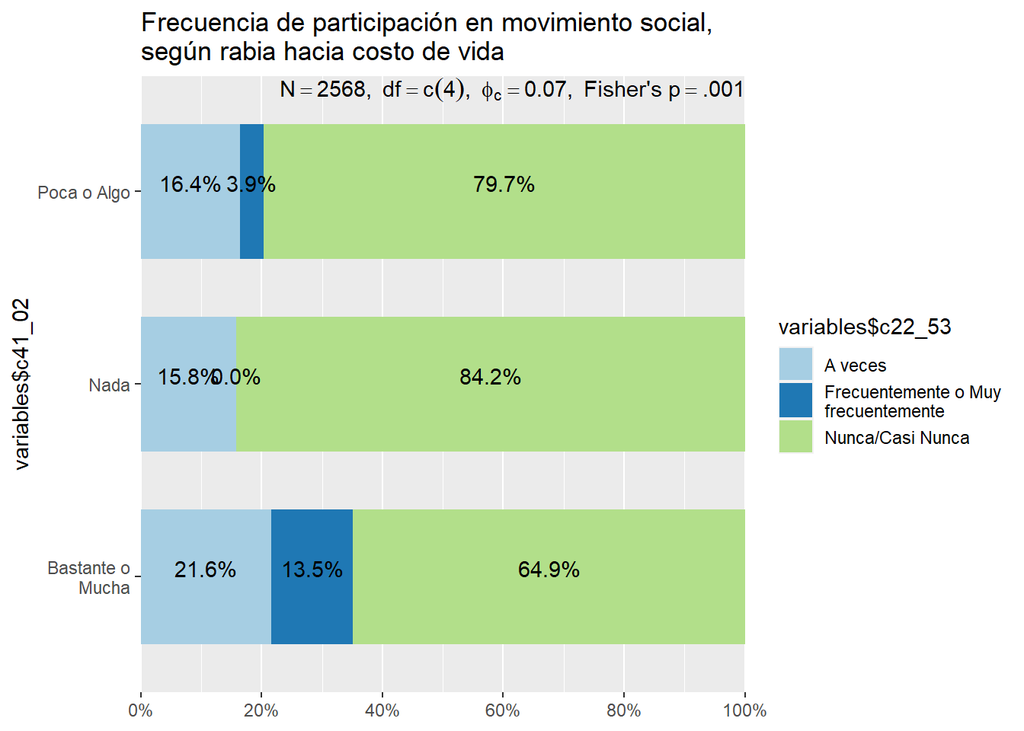

La frecuencia de participacion en los movimientos sociales, según el costo de vida, para las tres categorias “Bastante o mucha”, “Nada”, “Poca o Algo”, tienen altos porcentajes, muy parecidos al reporte original pero fue mencionado a lo largo del repote, desconocemos el por qué la diferencia de los resultados.

##Observación general

No conseguimos replicar los datos de manera correcta en los gráficos, suponemos que se debe a un error de procesamiento que no encontramos, o que quizás nuestros datos estaban incorrectos, ya que revisando variable por variable antes de procesar tampoco calzaban los porcentajes.